# IE425 Homework 3

Utku Atay, Sercan Demirkilic

11 06 2020

## Question 1

```r
library(ISLR)
library(caTools)
library(class)
library(caret)
library(xts)
library(car)
library(forecast)
library(readxl)
library(clusterCrit)
```

### a)

```r
credit <- read.csv("C:/Users/user/Desktop/Credit.csv")
str(credit)
```

```
## 'data.frame':    400 obs. of  12 variables:
##  $ X        : int  1 2 3 4 5 6 7 8 9 10 ...
##  $ Income   : num  14.9 106 104.6 148.9 55.9 ...
##  $ Limit    : int  3606 6645 7075 9504 4897 8047 3388 7114 3300 6819 ...
##  $ Rating   : int  283 483 514 681 357 569 259 512 266 491 ...
##  $ Cards    : int  2 3 4 3 2 4 2 2 5 3 ...
##  $ Age      : int  34 82 71 36 68 77 37 87 66 41 ...
##  $ Education: int  11 15 11 11 16 10 12 9 13 19 ...
##  $ Gender   : Factor w/ 2 levels " Male","Female": 1 2 1 2 1 1 2 1 2 2 ...
##  $ Student  : Factor w/ 2 levels "No","Yes": 1 2 1 1 1 1 1 1 1 2 ...
##  $ Married  : Factor w/ 2 levels "No","Yes": 2 2 1 1 2 1 1 1 1 2 ...
##  $ Ethnicity: Factor w/ 3 levels "African American",..: 3 2 2 2 3 3 1 2 3 1 ...
##  $ Balance  : int  333 903 580 964 331 1151 203 872 279 1350 ...
```

Firstly we are remooving the X values from the data because they are indicator of the row numbers. Since we are going to use regression they are unnecessary

```r
new_credit <- credit[,-1]
str(new_credit)
```

```
## 'data.frame':    400 obs. of  11 variables:
##  $ Income   : num  14.9 106 104.6 148.9 55.9 ...
##  $ Limit    : int  3606 6645 7075 9504 4897 8047 3388 7114 3300 6819 ...
##  $ Rating   : int  283 483 514 681 357 569 259 512 266 491 ...
##  $ Cards    : int  2 3 4 3 2 4 2 2 5 3 ...
##  $ Age      : int  34 82 71 36 68 77 37 87 66 41 ...
##  $ Education: int  11 15 11 11 16 10 12 9 13 19 ...
##  $ Gender   : Factor w/ 2 levels " Male","Female": 1 2 1 2 1 1 2 1 2 2 ...
##  $ Student  : Factor w/ 2 levels "No","Yes": 1 2 1 1 1 1 1 1 1 2 ...
##  $ Married  : Factor w/ 2 levels "No","Yes": 2 2 1 1 2 1 1 1 1 2 ...
##  $ Ethnicity: Factor w/ 3 levels "African American",..: 3 2 2 2 3 3 1 2 3 1 ...
##  $ Balance  : int  333 903 580 964 331 1151 203 872 279 1350 ...
```

```r
linear <- lm(Balance~. , data = new_credit)
summary(linear)
```

```
##
## Call:
## lm(formula = Balance ~ ., data = new_credit)
##
## Residuals:
##     Min      1Q  Median      3Q     Max
## -161.64  -77.70  -13.49   53.98  318.20
##
## Coefficients:
##                      Estimate Std. Error t value Pr(>|t|)
## (Intercept)        -479.20787   35.77394 -13.395  < 2e-16 ***
## Income               -7.80310    0.23423 -33.314  < 2e-16 ***
## Limit                 0.19091    0.03278   5.824 1.21e-08 ***
## Rating                1.13653    0.49089   2.315   0.0211 *
## Cards                17.72448    4.34103   4.083 5.40e-05 ***
## Age                  -0.61391    0.29399  -2.088   0.0374 *
## Education            -1.09886    1.59795  -0.688   0.4921
## GenderFemale        -10.65325    9.91400  -1.075   0.2832
## StudentYes          425.74736   16.72258  25.459  < 2e-16 ***
## MarriedYes           -8.53390   10.36287  -0.824   0.4107
## EthnicityAsian       16.80418   14.11906   1.190   0.2347
## EthnicityCaucasian   10.10703   12.20992   0.828   0.4083
## ---
## Signif. codes:  0 '***' 0.001 '**' 0.01 '*' 0.05 '.' 0.1 ' ' 1
##
## Residual standard error: 98.79 on 388 degrees of freedom
## Multiple R-squared:  0.9551, Adjusted R-squared:  0.9538
## F-statistic: 750.3 on 11 and 388 DF,  p-value: < 2.2e-16
```

```r
linear1 <- lm(Balance~ Income + Limit + Cards + Gender + Student, data = new_credit)
summary(linear1)
```

```
##
## Call:
## lm(formula = Balance ~ Income + Limit + Cards + Gender + Student,
##     data = new_credit)
##
## Residuals:
##     Min      1Q  Median      3Q     Max
## -196.43  -78.45  -10.95   50.76  328.88
##
## Coefficients:
##                Estimate Std. Error t value Pr(>|t|)
## (Intercept)  -4.943e+02  1.669e+01 -29.611  < 2e-16 ***
## Income       -7.847e+00  2.322e-01 -33.802  < 2e-16 ***
## Limit         2.668e-01  3.544e-03  75.277  < 2e-16 ***
## Cards         2.309e+01  3.640e+00   6.343 6.18e-10 ***
## GenderFemale -1.056e+01  9.984e+00  -1.058    0.291
## StudentYes    4.306e+02  1.663e+01  25.885  < 2e-16 ***
## ---
## Signif. codes:  0 '***' 0.001 '**' 0.01 '*' 0.05 '.' 0.1 ' ' 1
##
## Residual standard error: 99.54 on 394 degrees of freedom
## Multiple R-squared:  0.9537, Adjusted R-squared:  0.9531
## F-statistic:  1624 on 5 and 394 DF,  p-value: < 2.2e-16
```

```r
linear2 <- lm(Balance~ Income + Limit + Cards + Student, data = new_credit)
summary(linear2)
```

```
##
## Call:
## lm(formula = Balance ~ Income + Limit + Cards + Student, data = new_credit)
##
## Residuals:
##     Min      1Q  Median      3Q     Max
## -202.04  -80.41  -10.51   53.98  334.10
##
## Coefficients:
##               Estimate Std. Error t value Pr(>|t|)
## (Intercept) -4.997e+02  1.589e+01 -31.449  < 2e-16 ***
## Income      -7.839e+00  2.321e-01 -33.780  < 2e-16 ***
## Limit        2.666e-01  3.542e-03  75.271  < 2e-16 ***
## Cards        2.318e+01  3.639e+00   6.368 5.32e-10 ***
## StudentYes   4.296e+02  1.661e+01  25.862  < 2e-16 ***
## ---
## Signif. codes:  0 '***' 0.001 '**' 0.01 '*' 0.05 '.' 0.1 ' ' 1
##
## Residual standard error: 99.56 on 395 degrees of freedom
## Multiple R-squared:  0.9536, Adjusted R-squared:  0.9531
## F-statistic:  2029 on 4 and 395 DF,  p-value: < 2.2e-16
```

```r
gender_credit = split(new_credit , new_credit$Gender)
str(gender_credit)
```

```
## List of 2
##  $  Male :'data.frame':  193 obs. of  11 variables:
##   ..$ Income   : num [1:193] 14.9 104.6 55.9 80.2 71.4 ...
##   ..$ Limit    : int [1:193] 3606 7075 4897 8047 7114 8117 1311 6922 6626 2631 ...
##   ..$ Rating   : int [1:193] 283 514 357 569 512 589 138 511 479 213 ...
##   ..$ Cards    : int [1:193] 2 4 2 4 2 4 3 1 2 3 ...
##   ..$ Age      : int [1:193] 34 71 68 77 87 30 64 49 44 61 ...
##   ..$ Education: int [1:193] 11 11 16 10 9 14 16 9 9 10 ...
##   ..$ Gender   : Factor w/ 2 levels " Male","Female": 1 1 1 1 1 1 1 1 1 1 ...
##   ..$ Student  : Factor w/ 2 levels "No","Yes": 1 1 1 1 1 1 1 1 1 1 ...
##   ..$ Married  : Factor w/ 2 levels "No","Yes": 2 1 2 1 1 2 1 2 1 2 ...
##   ..$ Ethnicity: Factor w/ 3 levels "African American",..: 3 2 3 3 2 3 3 3 2 1 ...
##   ..$ Balance  : int [1:193] 333 580 331 1151 872 1407 0 1081 1048 0 ...
##  $ Female:'data.frame':  207 obs. of  11 variables:
##   ..$ Income   : num [1:207] 106 148.9 21 15.1 71.1 ...
##   ..$ Limit    : int [1:207] 6645 9504 3388 3300 6819 5308 3291 2525 3714 4378 ...
##   ..$ Rating   : int [1:207] 483 681 259 266 491 394 269 200 286 339 ...
##   ..$ Cards    : int [1:207] 3 3 2 5 3 1 2 3 3 3 ...
##   ..$ Age      : int [1:207] 82 36 37 66 41 57 75 57 73 69 ...
##   ..$ Education: int [1:207] 15 11 12 13 19 7 13 15 17 15 ...
##   ..$ Gender   : Factor w/ 2 levels " Male","Female": 2 2 2 2 2 2 2 2 2 2 ...
##   ..$ Student  : Factor w/ 2 levels "No","Yes": 2 1 1 1 2 1 1 1 1 1 ...
##   ..$ Married  : Factor w/ 2 levels "No","Yes": 2 1 1 1 2 2 1 2 2 2 ...
##   ..$ Ethnicity: Factor w/ 3 levels "African American",..: 2 2 1 3 1 2 1 1 1 2 ...
##   ..$ Balance  : int [1:207] 903 964 203 279 1350 204 148 0 0 368 ...
```

```r
female_balance <- mean(gender_credit$Female$Balance)
female_balance
```

```
## [1] 529.5362
```

```r
male_balance <- mean(gender_credit$` Male`$Balance)
male_balance
```

```
## [1] 509.8031
```

### b)

```r
linear3 <- lm(Balance~ Income + Limit + Cards + Student + Ethnicity, data = new_credit)
summary(linear3)
```

```
##
## Call:
## lm(formula = Balance ~ Income + Limit + Cards + Student + Ethnicity,
##     data = new_credit)
##
## Residuals:
##     Min      1Q  Median      3Q     Max
## -203.56  -77.85   -9.02   53.34  343.54
##
## Coefficients:
##                      Estimate Std. Error t value Pr(>|t|)
## (Intercept)        -5.092e+02  1.829e+01 -27.842  < 2e-16 ***
## Income             -7.837e+00  2.324e-01 -33.725  < 2e-16 ***
## Limit               2.667e-01  3.547e-03  75.187  < 2e-16 ***
## Cards               2.317e+01  3.643e+00   6.360 5.62e-10 ***
## StudentYes          4.293e+02  1.665e+01  25.775  < 2e-16 ***
## EthnicityAsian      1.534e+01  1.408e+01   1.090    0.276
## EthnicityCaucasian  1.049e+01  1.227e+01   0.855    0.393
## ---
## Signif. codes:  0 '***' 0.001 '**' 0.01 '*' 0.05 '.' 0.1 ' ' 1
##
## Residual standard error: 99.65 on 393 degrees of freedom
## Multiple R-squared:  0.9537, Adjusted R-squared:  0.953
## F-statistic:  1350 on 6 and 393 DF,  p-value: < 2.2e-16
```

```r
linear4 <- lm(Balance~ Ethnicity, data = new_credit)
summary(linear4)
```

```
##
## Call:
## lm(formula = Balance ~ Ethnicity, data = new_credit)
##
## Residuals:
##     Min      1Q  Median      3Q     Max
## -531.00 -457.08  -63.25  339.25 1480.50
##
## Coefficients:
##                    Estimate Std. Error t value Pr(>|t|)
## (Intercept)          531.00      46.32  11.464   <2e-16 ***
## EthnicityAsian       -18.69      65.02  -0.287    0.774
## EthnicityCaucasian   -12.50      56.68  -0.221    0.826
## ---
## Signif. codes:  0 '***' 0.001 '**' 0.01 '*' 0.05 '.' 0.1 ' ' 1
##
## Residual standard error: 460.9 on 397 degrees of freedom
## Multiple R-squared:  0.0002188,  Adjusted R-squared:  -0.004818
## F-statistic: 0.04344 on 2 and 397 DF,  p-value: 0.9575
```

WHen we add etnicity variable to our model, adjusted R squared decreasing a little. Additionally p value is high and importance of ethnicity is very low. Therefore, we can say that Ethnicity has no significant effect on the balance.

### c)

```r
student_credit <-split(new_credit , new_credit$Student)
str(student_credit)
```

```
## List of 2
##  $ No :'data.frame': 360 obs. of  11 variables:
##   ..$ Income   : num [1:360] 14.9 104.6 148.9 55.9 80.2 ...
##   ..$ Limit    : int [1:360] 3606 7075 9504 4897 8047 3388 7114 3300 8117 1311 ...
##   ..$ Rating   : int [1:360] 283 514 681 357 569 259 512 266 589 138 ...
##   ..$ Cards    : int [1:360] 2 4 3 2 4 2 2 5 4 3 ...
##   ..$ Age      : int [1:360] 34 71 36 68 77 37 87 66 30 64 ...
##   ..$ Education: int [1:360] 11 11 11 16 10 12 9 13 14 16 ...
##   ..$ Gender   : Factor w/ 2 levels " Male","Female": 1 1 2 1 1 2 1 2 1 1 ...
##   ..$ Student  : Factor w/ 2 levels "No","Yes": 1 1 1 1 1 1 1 1 1 1 ...
##   ..$ Married  : Factor w/ 2 levels "No","Yes": 2 1 1 2 1 1 1 1 2 1 ...
##   ..$ Ethnicity: Factor w/ 3 levels "African American",..: 3 2 2 3 3 1 2 3 3 3 ...
##   ..$ Balance  : int [1:360] 333 580 964 331 1151 203 872 279 1407 0 ...
##  $ Yes:'data.frame': 40 obs. of  11 variables:
##   ..$ Income   : num [1:40] 106 71.1 42.5 23.4 113.7 ...
##   ..$ Limit    : int [1:40] 6645 6819 3625 2558 7659 5043 4431 4569 3293 5382 ...
##   ..$ Rating   : int [1:40] 483 491 289 220 538 376 320 354 251 367 ...
##   ..$ Cards    : int [1:40] 3 3 6 3 2 2 2 4 1 1 ...
##   ..$ Age      : int [1:40] 82 41 44 49 66 64 49 49 68 59 ...
##   ..$ Education: int [1:40] 15 19 12 12 15 16 15 13 16 17 ...
##   ..$ Gender   : Factor w/ 2 levels " Male","Female": 2 2 2 2 1 2 1 1 1 1 ...
##   ..$ Student  : Factor w/ 2 levels "No","Yes": 2 2 2 2 2 2 2 2 2 2 ...
##   ..$ Married  : Factor w/ 2 levels "No","Yes": 2 2 1 1 2 2 2 2 1 1 ...
##   ..$ Ethnicity: Factor w/ 3 levels "African American",..: 2 1 3 3 1 2 3 1 3 2 ...
##   ..$ Balance  : int [1:40] 903 1350 654 419 1155 1241 797 902 532 1380 ...
```

```r
student_linear_yes <- lm(Balance~ Income , data = student_credit$Yes)
summary(student_linear_yes)
```

```
##
## Call:
## lm(formula = Balance ~ Income, data = student_credit$Yes)
##
## Residuals:
##     Min      1Q  Median      3Q     Max
## -749.55 -372.56   51.38  454.78  730.63
##
## Coefficients:
##             Estimate Std. Error t value Pr(>|t|)
## (Intercept)  677.299    118.088   5.736 1.31e-06 ***
## Income         4.219      1.945   2.169   0.0364 *
## ---
## Signif. codes:  0 '***' 0.001 '**' 0.01 '*' 0.05 '.' 0.1 ' ' 1
##
## Residual standard error: 468.3 on 38 degrees of freedom
## Multiple R-squared:  0.1102, Adjusted R-squared:  0.08674
## F-statistic: 4.704 on 1 and 38 DF,  p-value: 0.03642
```

```r
student_linear_no <- lm(Balance~ Income , data = student_credit$No)
summary(student_linear_no)
```

```
##
## Call:
## lm(formula = Balance ~ Income, data = student_credit$No)
##
## Residuals:
##    Min     1Q Median     3Q    Max
## -773.4 -325.5  -43.1  314.4  814.0
##
## Coefficients:
##             Estimate Std. Error t value Pr(>|t|)
## (Intercept) 200.6232    32.9209   6.094 2.85e-09 ***
## Income        6.2182     0.5784  10.750  < 2e-16 ***
## ---
## Signif. codes:  0 '***' 0.001 '**' 0.01 '*' 0.05 '.' 0.1 ' ' 1
##
## Residual standard error: 382.6 on 358 degrees of freedom
## Multiple R-squared:  0.244,  Adjusted R-squared:  0.2419
## F-statistic: 115.6 on 1 and 358 DF,  p-value: < 2.2e-16
```

In this part we are checking the income variable has a different effect for the student compared to non student. We are spliting our data according to student attribute. Then we built two different models with only income variable. As we see R squared score is higher in second model so we can say that effect of income on balance is significantly higher for non-students compared to students.

### d)

```r
linear_age_limit <- lm(Balance ~ Age + Limit , data=new_credit)
summary(linear_age_limit)
```

```
##
## Call:
## lm(formula = Balance ~ Age + Limit, data = new_credit)
##
## Residuals:
##     Min      1Q  Median      3Q     Max
## -696.84 -150.78  -13.01  126.68  755.56
##
## Coefficients:
##               Estimate Std. Error t value Pr(>|t|)
## (Intercept) -1.734e+02  4.383e+01  -3.957 9.01e-05 ***
## Age         -2.291e+00  6.725e-01  -3.407 0.000723 ***
## Limit        1.734e-01  5.026e-03  34.496  < 2e-16 ***
## ---
## Signif. codes:  0 '***' 0.001 '**' 0.01 '*' 0.05 '.' 0.1 ' ' 1
##
## Residual standard error: 230.5 on 397 degrees of freedom
## Multiple R-squared:  0.7498, Adjusted R-squared:  0.7486
## F-statistic:   595 on 2 and 397 DF,  p-value: < 2.2e-16
```

```r
vif1 <- vif(linear_age_limit)
vif1
```

```
##      Age    Limit
## 1.010283 1.010283
```

```r
linear_rating_limit <- lm(Balance ~ Rating + Limit , data=new_credit)
summary(linear_rating_limit)
```

```
##
## Call:
## lm(formula = Balance ~ Rating + Limit, data = new_credit)
##
## Residuals:
##    Min     1Q Median     3Q    Max
## -707.8 -135.9   -9.5  124.0  817.6
##
## Coefficients:
##               Estimate Std. Error t value Pr(>|t|)
## (Intercept) -377.53680   45.25418  -8.343 1.21e-15 ***
## Rating         2.20167    0.95229   2.312   0.0213 *
## Limit          0.02451    0.06383   0.384   0.7012
## ---
## Signif. codes:  0 '***' 0.001 '**' 0.01 '*' 0.05 '.' 0.1 ' ' 1
##
## Residual standard error: 232.3 on 397 degrees of freedom
## Multiple R-squared:  0.7459, Adjusted R-squared:  0.7447
## F-statistic: 582.8 on 2 and 397 DF,  p-value: < 2.2e-16
```

```r
vif2 <- vif(linear_rating_limit)
vif2
```

```
##   Rating    Limit
## 160.4933 160.4933
```

```r
linear_rating <- lm(Balance ~ Rating, data=new_credit)
summary(linear_rating)
```

```
##
## Call:
## lm(formula = Balance ~ Rating, data = new_credit)
##
## Residuals:
##     Min      1Q  Median      3Q     Max
## -712.28 -135.32   -9.58  125.67  829.04
##
## Coefficients:
##               Estimate Std. Error t value Pr(>|t|)
## (Intercept) -390.84634   29.06851  -13.45   <2e-16 ***
## Rating         2.56624    0.07509   34.18   <2e-16 ***
## ---
## Signif. codes:  0 '***' 0.001 '**' 0.01 '*' 0.05 '.' 0.1 ' ' 1
##
## Residual standard error: 232.1 on 398 degrees of freedom
## Multiple R-squared:  0.7458, Adjusted R-squared:  0.7452
## F-statistic:  1168 on 1 and 398 DF,  p-value: < 2.2e-16
```

```r
linear_limit <- lm(Balance ~ Limit , data=new_credit)
summary(linear_limit)
```

```
##
## Call:
## lm(formula = Balance ~ Limit, data = new_credit)
##
## Residuals:
##     Min      1Q  Median      3Q     Max
## -676.95 -141.87  -11.55  134.11  776.44
##
## Coefficients:
##               Estimate Std. Error t value Pr(>|t|)
## (Intercept) -2.928e+02  2.668e+01  -10.97   <2e-16 ***
## Limit        1.716e-01  5.066e-03   33.88   <2e-16 ***
## ---
## Signif. codes:  0 '***' 0.001 '**' 0.01 '*' 0.05 '.' 0.1 ' ' 1
##
## Residual standard error: 233.6 on 398 degrees of freedom
## Multiple R-squared:  0.7425, Adjusted R-squared:  0.7419
## F-statistic:  1148 on 1 and 398 DF,  p-value: < 2.2e-16
```

As we see the first model’s r squared score is higher than the second but not significantly. If we looked into the result of the vif functions we can see that Rating and limit has a large value so that they are correlated. If we looked them seperately both have a significant effect on balance however when they applied together one is becoming insignificant. If we looked into Age and Limit see that they are notcorrelated that much because of the smaller vif value.

## Question 2

### a)

In order to determine the clusters of the passengers who have the similar characteristics we applied hierarchical clustering first.Since not all the attributes are not in the same unit we need to scale our data before applying clustering. To do this, we used scale function.And we used scaled data for clustering. We applied a complete linkage in this hierarchical clustering with Euclidean distance.To determine the number of clusters which are appropriate, we used the cutree function and gave 8 numbers to k from 1 to 8. We created 8 different scenarios. And then compare them by investigating the number of members of each cluster in each scenario. According to this scenario, the best number of clusters is 6. However, when we check the silhoutte index, best number of clusters is 2. If we want to have more than 2 clusters, then we can divide 6 clusters. In this question, we think that we have minimum 3-4 clusters to identify each groups and differentiate them from others.

```r
airlines <- read_xlsx("C:/Users/user/Desktop/EastWestAirlines.xlsx",3)
str(airlines)
```

```
## Classes 'tbl_df', 'tbl' and 'data.frame':    3999 obs. of  12 variables:
##  $ ID               : num  1 2 3 4 5 6 7 8 9 10 ...
##  $ Balance          : num  28143 19244 41354 14776 97752 ...
##  $ Qual_miles       : num  0 0 0 0 0 0 0 0 0 0 ...
##  $ cc1_miles        : num  1 1 1 1 4 1 3 1 3 3 ...
##  $ cc2_miles        : num  1 1 1 1 1 1 1 1 2 1 ...
##  $ cc3_miles        : num  1 1 1 1 1 1 1 1 1 1 ...
##  $ Bonus_miles      : num  174 215 4123 500 43300 ...
##  $ Bonus_trans      : num  1 2 4 1 26 0 25 4 43 28 ...
##  $ Flight_miles_12mo: num  0 0 0 0 2077 ...
##  $ Flight_trans_12  : num  0 0 0 0 4 0 0 1 12 3 ...
##  $ Days_since_enroll: num  7000 6968 7034 6952 6935 ...
##  $ Award            : num  0 0 0 0 1 0 0 1 1 1 ...
```

```r
scale_airlines <- scale(airlines[,2:12])
str(scale_airlines)
```

```
##  num [1:3999, 1:11] -0.451 -0.539 -0.32 -0.584 0.24 ...
##  - attr(*, "dimnames")=List of 2
##   ..$ : NULL
##   ..$ : chr [1:11] "Balance" "Qual_miles" "cc1_miles" "cc2_miles" ...
##  - attr(*, "scaled:center")= Named num [1:11] 73601.33 144.11 2.06 1.01 1.01 ...
##   ..- attr(*, "names")= chr [1:11] "Balance" "Qual_miles" "cc1_miles" "cc2_miles" ...
##  - attr(*, "scaled:scale")= Named num [1:11] 1.01e+05 7.74e+02 1.38 1.48e-01 1.95e-01 ...
##   ..- attr(*, "names")= chr [1:11] "Balance" "Qual_miles" "cc1_miles" "cc2_miles" ...
```

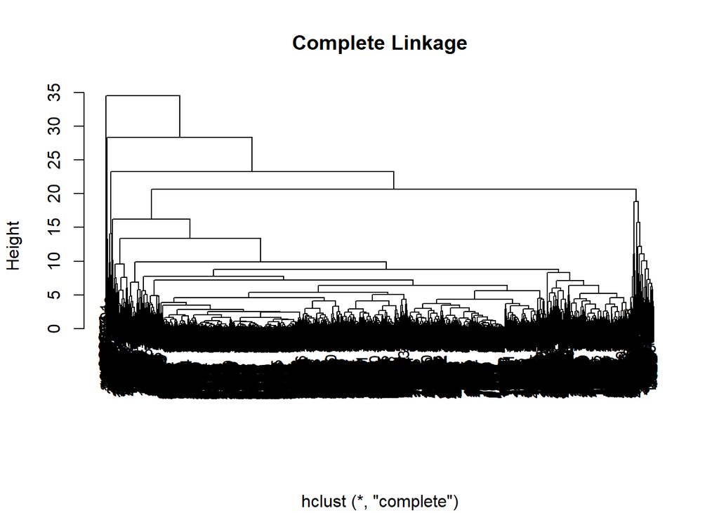

```r
complete_airlines <- hclust(dist(scale_airlines, method = "euclidean" ), method = "complete")
plot(complete_airlines , main="Complete Linkage", xlab="", cex=0.9)
```

```r
y <- cutree(complete_airlines, k = c(1:8))
table(y[,"2"], y[,"3"])
```

```
##
##        1    2    3
##   1 3980   15    0
##   2    0    0    4
```

```r
table(y[,"3"], y[,"4"])
```

```
##
##        1    2    3    4
##   1 3952   28    0    0
##   2    0    0   15    0
##   3    0    0    0    4
```

```r
table(y[,"4"], y[,"5"])
```

```
##
##        1    2    3    4    5
##   1 3782  170    0    0    0
##   2    0    0   28    0    0
##   3    0    0    0   15    0
##   4    0    0    0    0    4
```

```r
table(y[,"5"], y[,"6"])
```

```
##
##        1    2    3    4    5    6
##   1 3782    0    0    0    0    0
##   2    0   43  127    0    0    0
##   3    0    0    0   28    0    0
##   4    0    0    0    0   15    0
##   5    0    0    0    0    0    4
```

```r
table(y[,"6"], y[,"7"])
```

```
##
##        1    2    3    4    5    6    7
##   1 3771    0    0    0    0   11    0
##   2    0   43    0    0    0    0    0
##   3    0    0  127    0    0    0    0
##   4    0    0    0   28    0    0    0
##   5    0    0    0    0   15    0    0
##   6    0    0    0    0    0    0    4
```

```r
intCriteria(scale_airlines,cutree(complete_airlines, k=2),c("silhouette"))
```

```
## $silhouette
## [1] 0.6911827
```

```r
intCriteria(scale_airlines,cutree(complete_airlines, k=3),c("silhouette"))
```

```
## $silhouette
## [1] 0.6362012
```

```r
intCriteria(scale_airlines,cutree(complete_airlines, k=4),c("silhouette"))
```

```
## $silhouette
## [1] 0.5137551
```

```r
intCriteria(scale_airlines,cutree(complete_airlines, k=5),c("silhouette"))
```

```
## $silhouette
## [1] 0.3826405
```

```r
intCriteria(scale_airlines,cutree(complete_airlines, k=6),c("silhouette"))
```

```
## $silhouette
## [1] 0.4070834
```

### b)

To give labels to each cluster, we need to compare their centroids. In order to calculate each centroid we used the algorithm below.

```r
clusters <- cutree(complete_airlines, k= 6)
clusters_centroid <- function(i, dat, clusters) {
  ind = (clusters == i)
  colMeans(dat[ind,])
}
sapply(unique(clusters), clusters_centroid, airlines, clusters)
```

```
##                           [,1]         [,2]         [,3]         [,4]
## ID                2.037481e+03 2.269372e+03 1.551213e+03 6.942500e+02
## Balance           6.590207e+04 6.887658e+04 1.334593e+05 8.064333e+05
## Qual_miles        1.373707e+02 2.325581e+01 3.344724e+02 3.832143e+02
## cc1_miles         2.033580e+00 1.139535e+00 2.629921e+00 3.571429e+00
## cc2_miles         1.000000e+00 2.348837e+00 1.000000e+00 1.000000e+00
## cc3_miles         1.000793e+00 1.000000e+00 1.000000e+00 1.000000e+00
## Bonus_miles       1.557137e+04 1.468984e+04 4.513902e+04 5.841232e+04
## Bonus_trans       1.072448e+01 1.753488e+01 2.984252e+01 2.121429e+01
## Flight_miles_12mo 2.705854e+02 5.826279e+02 5.246244e+03 1.344393e+03
## Flight_trans_12   8.183501e-01 2.209302e+00 1.515748e+01 5.607143e+00
## Days_since_enroll 4.072295e+03 3.968930e+03 4.949787e+03 6.835893e+03
## Award             3.503437e-01 3.953488e-01 8.110236e-01 8.571429e-01
##                           [,5]      [,6]
## ID                1.664867e+03   3128.00
## Balance           1.380614e+05 131999.50
## Qual_miles        7.880000e+01    347.00
## cc1_miles         3.466667e+00      2.50
## cc2_miles         1.000000e+00      1.00
## cc3_miles         4.066667e+00      1.00
## Bonus_miles       9.392787e+04  65634.25
## Bonus_trans       2.806667e+01     69.25
## Flight_miles_12mo 5.066667e+02  19960.00
## Flight_trans_12   1.600000e+00     49.25
## Days_since_enroll 4.613867e+03   2200.25
## Award             5.333333e-01      1.00
```

These are the centroids of each clusters with respect to each attribute. By comparing them we tried to determine labels to each cluster and categorize the customers. Here are our proposed labels and outcomes regarding each cluster: 1) Least Frequent Flyers: Since, they have the lowest Balance, we give this label. 2) Rewards Credit Card Users: Since, they have the highest cc2_miles, we give this label. 3) Ordinary Users: Since, we see no prominent feature for them, we give this label. 4) Rich in Mile Users: Since, they have the highest Balance, we give this label. 5) Small Business Credit Card Users: Since, they have the highest cc3_miles, we give this label. 6) Last 12 months’ Most Active Flyers: Since, they have the highest Bonus_trans, Flight_miles_12mo and Flight_trans_12, we give this label.

### c)

```r
set.seed(425)
split_airlines <- sample.split(airlines$ID, SplitRatio = 0.95)
airlines1 <- subset(airlines, split_airlines == TRUE)
airlines2 <- subset(airlines, split_airlines == FALSE)

str(airlines1)
```

```
## Classes 'tbl_df', 'tbl' and 'data.frame':    3799 obs. of  12 variables:
##  $ ID               : num  1 2 3 4 5 6 7 8 9 10 ...
##  $ Balance          : num  28143 19244 41354 14776 97752 ...
##  $ Qual_miles       : num  0 0 0 0 0 0 0 0 0 0 ...
##  $ cc1_miles        : num  1 1 1 1 4 1 3 1 3 3 ...
##  $ cc2_miles        : num  1 1 1 1 1 1 1 1 2 1 ...
##  $ cc3_miles        : num  1 1 1 1 1 1 1 1 1 1 ...
##  $ Bonus_miles      : num  174 215 4123 500 43300 ...
##  $ Bonus_trans      : num  1 2 4 1 26 0 25 4 43 28 ...
##  $ Flight_miles_12mo: num  0 0 0 0 2077 ...
##  $ Flight_trans_12  : num  0 0 0 0 4 0 0 1 12 3 ...
##  $ Days_since_enroll: num  7000 6968 7034 6952 6935 ...
##  $ Award            : num  0 0 0 0 1 0 0 1 1 1 ...
```

```r
str(airlines2)
```

```
## Classes 'tbl_df', 'tbl' and 'data.frame':    200 obs. of  12 variables:
##  $ ID               : num  107 119 152 167 177 191 203 207 215 237 ...
##  $ Balance          : num  34327 143967 24868 80331 120941 ...
##  $ Qual_miles       : num  0 0 0 0 0 0 0 0 0 0 ...
##  $ cc1_miles        : num  1 2 1 3 4 1 4 5 1 2 ...
##  $ cc2_miles        : num  1 1 1 1 1 1 1 1 1 1 ...
##  $ cc3_miles        : num  1 1 1 1 1 1 1 1 1 1 ...
##  $ Bonus_miles      : num  0 7346 205 15489 42301 ...
##  $ Bonus_trans      : num  0 11 5 18 21 8 17 18 8 13 ...
##  $ Flight_miles_12mo: num  0 0 0 0 0 0 150 500 0 0 ...
##  $ Flight_trans_12  : num  0 0 0 0 0 0 1 1 0 0 ...
##  $ Days_since_enroll: num  6745 7689 6689 7634 7588 ...
##  $ Award            : num  0 0 0 1 0 0 1 1 0 1 ...
```

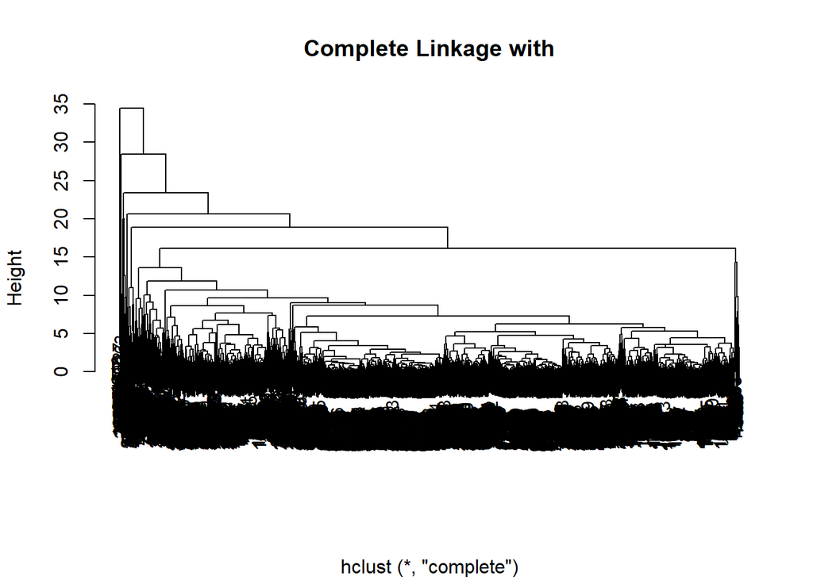

```r
scale_airlines1 <- scale(airlines1)
complete_airlines1 <-  hclust(dist(scale_airlines1, method = "euclidean" ), method = "complete")
plot(complete_airlines1 , main="Complete Linkage with", xlab="", cex=0.9)
```

```r
y1 <- cutree(complete_airlines1, k = c(1:8))

table(y1[,"2"], y1[,"3"])
```

```
##
##        1    2    3
##   1 3783   14    0
##   2    0    0    2
```

```r
table(y1[,"3"], y1[,"4"])
```

```
##
##        1    2    3    4
##   1 3758   25    0    0
##   2    0    0   14    0
##   3    0    0    0    2
```

```r
table(y1[,"4"], y1[,"5"])
```

```
##
##        1    2    3    4    5
##   1 3747    0    0   11    0
##   2    0   25    0    0    0
##   3    0    0   14    0    0
##   4    0    0    0    0    2
```

```r
table(y1[,"5"], y1[,"6"])
```

```
##
##        1    2    3    4    5    6
##   1 3747    0    0    0    0    0
##   2    0   20    0    5    0    0
##   3    0    0   14    0    0    0
##   4    0    0    0    0   11    0
##   5    0    0    0    0    0    2
```

```r
table(y1[,"6"], y1[,"7"])
```

```
##
##        1    2    3    4    5    6    7
##   1 3704   43    0    0    0    0    0
##   2    0    0   20    0    0    0    0
##   3    0    0    0   14    0    0    0
##   4    0    0    0    0    5    0    0
##   5    0    0    0    0    0   11    0
##   6    0    0    0    0    0    0    2
```

```r
table(y1[,"7"], y1[,"8"])
```

```
##
##        1    2    3    4    5    6    7    8
##   1 3676    0    0   28    0    0    0    0
##   2    0   43    0    0    0    0    0    0
##   3    0    0   20    0    0    0    0    0
##   4    0    0    0    0   14    0    0    0
##   5    0    0    0    0    0    5    0    0
##   6    0    0    0    0    0    0   11    0
##   7    0    0    0    0    0    0    0    2
```

### d)

```r
airlines_kmeans <- kmeans(scale_airlines, centers= 6 , nstart = 10)
str(airlines_kmeans)
```

```
## List of 9
##  $ cluster     : int [1:3999] 6 6 6 6 1 6 1 2 3 1 ...
##  $ centers     : num [1:6, 1:11] 0.6284 -0.1577 -0.0469 0.4254 1.1975 ...
##   ..- attr(*, "dimnames")=List of 2
##   .. ..$ : chr [1:6] "1" "2" "3" "4" ...
##   .. ..$ : chr [1:11] "Balance" "Qual_miles" "cc1_miles" "cc2_miles" ...
##  $ totss       : num 43978
##  $ withinss    : num [1:6] 5821 2766 727 789 7555 ...
##  $ tot.withinss: num 22724
##  $ betweenss   : num 21254
##  $ size        : int [1:6] 895 805 43 55 136 2065
##  $ iter        : int 3
##  $ ifault      : int 0
##  - attr(*, "class")= chr "kmeans"
```

```r
airlines_kmeans$betweenss
```

```
## [1] 21253.87
```

```r
airlines_kmeans$withinss
```

```
## [1] 5820.8776 2765.6933  727.0617  789.1198 7555.2516 5066.1283
```

```r
airlines_kmeans$tot.withinss
```

```
## [1] 22724.13
```

```r
airlines_kmeans$totss
```

```
## [1] 43978
```

### e)

We prepared special marketing plans and offers for each cluster. You can find them below:

For Least Frequent Flyers; They don’t fly as much as other clusters with East-West Airlines. We believe that the reason is mostly financial. Therefore, the airline should deliver them some special offers and cheap tickets. For instance, there may be 40% discount for ticket prices at special dates such as national holidays.

For Rewards Credit Card Users; We believe that they use rewards credit card a lot due to its mileage earning system. However, their balance is low, because they don’t use other ways to earn miles. They don’t fly frequently as well. Since, they like to earn miles, the airline may offer them other mileage earning channels such as frequent flyer credit cards or small business credit cards.

For Ordinary Users; This cluster may be in the scope of every marketing campaign, because they don’t have any prominent features. However, we suggest using more general campaigns rather than more specialized ones. For example, regular follow-up emails or promotions can be sent to this customer segment.

For Rich in Mile Users; They have lots of miles that can be used while purchasing flight tickets. Therefore, the airline may offer them to get reward tickets for a smaller number of miles. This campaign may increase their loyalty to the brand.

For Small Business Credit Card Users; Since, they are a unique and niche customer segment, the airline may address their “Small Business” title and by using this title, some customized marketing campaigns could be prepared. For example, some discount may be applied while purchasing flight tickets using small business credit cards only. Their loyalty is expected to rise by that way.

For Last 12 months’ Most Active Flyers; The customers in this segment are the ones who flied most in last 12 months. Therefore, their average annual income is expected to be higher compared to other segments. For this customer segment, the airline may deliver premium offers such as discount for business class seats or in-flight food purchases. Thus, East-West could increase its revenue.